# XAI Case Studies 2022L - Homework 1

Hoang Thien Ly

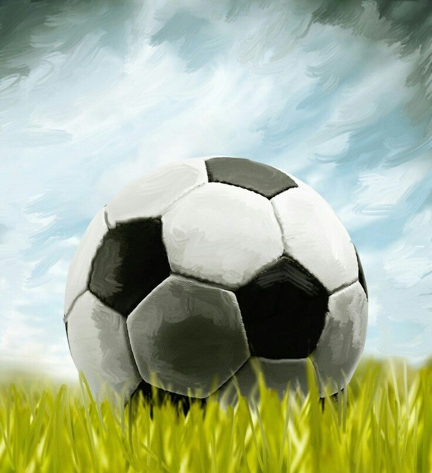

## Loading dataset & data preparation:

Package {worldfootballr} was removed from CRAN. So it’s quite enigmatic to install the package, even directly from Github page (it crashed). So the solution I used is to run remotely on RStudio Cloud, then export the csv form of dataset (by scraping dataset from https://understat.com/). Miraculously it worked! Below is the dataset taken from 2021 for EPL league

```r
EPL_2021 <- read.csv("C:/Users/DELL/OneDrive/Desktop/EPL_2021.csv")
head(EPL_2021)
```

|  | league | id | minute | result | X | Y | xG | player | h_a | player_id | situation | season | shotType | match_id | home_team | away_team | home_goals | away_goals | date | player_assisted | lastAction |
| --- | --- | --- | --- | --- | --- | --- | --- | --- | --- | --- | --- | --- | --- | --- | --- | --- | --- | --- | --- | --- | --- |
| 1 | EPL | 425564 | 10 | MissedShots | 0.913 | 0.539 | 0.05346401 | Frank Onyeka | h | 9681 | OpenPlay | 2021 | Head | 16376 | Brentford | Arsenal | 2 | 0 | 2021-08-13 19:00:00 | NA | Aerial |
| 2 | EPL | 425565 | 11 | ShotOnPost | 0.908 | 0.315 | 0.11829661 | Bryan Mbeumo | h | 6552 | OpenPlay | 2021 | RightFoot | 16376 | Brentford | Arsenal | 2 | 0 | 2021-08-13 19:00:00 | Ivan Toney | Throughball |
| 3 | EPL | 425567 | 21 | Goal | 0.874 | 0.698 | 0.05214472 | Sergi Canos | h | 1078 | OpenPlay | 2021 | RightFoot | 16376 | Brentford | Arsenal | 2 | 0 | 2021-08-13 19:00:00 | Ethan Pinnock | BallRecovery |
| 4 | EPL | 425568 | 27 | MissedShots | 0.812 | 0.478 | 0.06570620 | Sergi Canos | h | 1078 | OpenPlay | 2021 | RightFoot | 16376 | Brentford | Arsenal | 2 | 0 | 2021-08-13 19:00:00 | Frank Onyeka | Pass |
| 5 | EPL | 425569 | 29 | MissedShots | 0.892 | 0.357 | 0.08069062 | Bryan Mbeumo | h | 6552 | OpenPlay | 2021 | RightFoot | 16376 | Brentford | Arsenal | 2 | 0 | 2021-08-13 19:00:00 | Kristoffer Ajer | Chipped |
| 6 | EPL | 425579 | 65 | SavedShot | 0.882 | 0.332 | 0.07258376 | Sergi Canos | h | 1078 | OpenPlay | 2021 | RightFoot | 16376 | Brentford | Arsenal | 2 | 0 | 2021-08-13 19:00:00 | Bryan Mbeumo | Pass |

In brief, value of xG ranges between zero and one to each shot which represents the probability that the shot will result in a goal.

From our dataset, some features are obviously indespensable: X, Y (coordinate of the shot), shotType (body part used to take the shot), home_goals and away_goals (to give a brief overview of the player’s ability) and result (Goal/Missed Shots/…)

The remained features, better to be removed, to accelerate running times of built models (league: only one league EPL, id of the shot - brings no new info, minute - in reality, soccer players are often substituted during the game, player - no need, since more or less, performance of soccer players is stored in home_goals & away_goals, match_id: no repetition in the future data, meaningless for models, date, player_assited - we don’t have info about that player)

We transform the coordinates X and Y into distance to Goal and angle to Goal

```r
library(dplyr)
df_1 <- EPL_2021 %>% select(result, X, Y, xG, h_a, situation, shotType, home_goals, away_goals, lastAction) %>%
                 mutate(status = ifelse(result == "Goal", "1", "0")) %>%
                 mutate(distanceToGoal = sqrt((105 - (X * 105)) ^ 2 + (32.5 - (Y * 68)) ^ 2)) %>%
                 mutate(angleToGoal = abs(atan((7.32 * (105 - (X * 105))) / ((105 - (X * 105))^2 +
                (32.5 - (Y * 68)) ^ 2 - (7.32 / 2) ^ 2)) * 180 / pi)) %>%
                 select(-X, -Y, -result)
```

## Exploratory Data Analysis:

```r
library(autoEDA)
autoEDA::autoEDA(df_1)
```

```
## autoEDA | Setting color theme
## autoEDA | Removing constant features
## autoEDA | 0 constant features removed
## autoEDA | 0 zero spread features removed
## autoEDA | Removing features containing majority missing values
## autoEDA | 0 majority missing features removed
## autoEDA | Cleaning data
## autoEDA | Correcting sparse categorical feature levels
## autoEDA | Performing univariate analysis
## autoEDA | Visualizing data
```

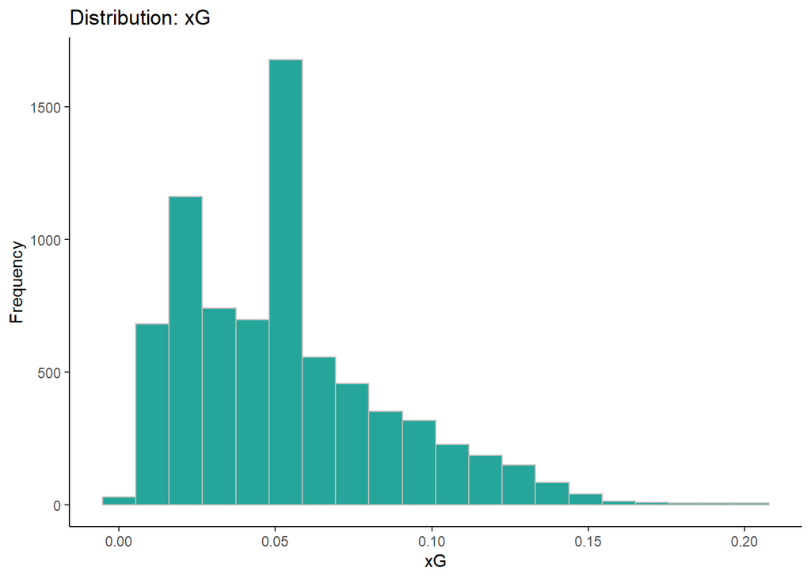

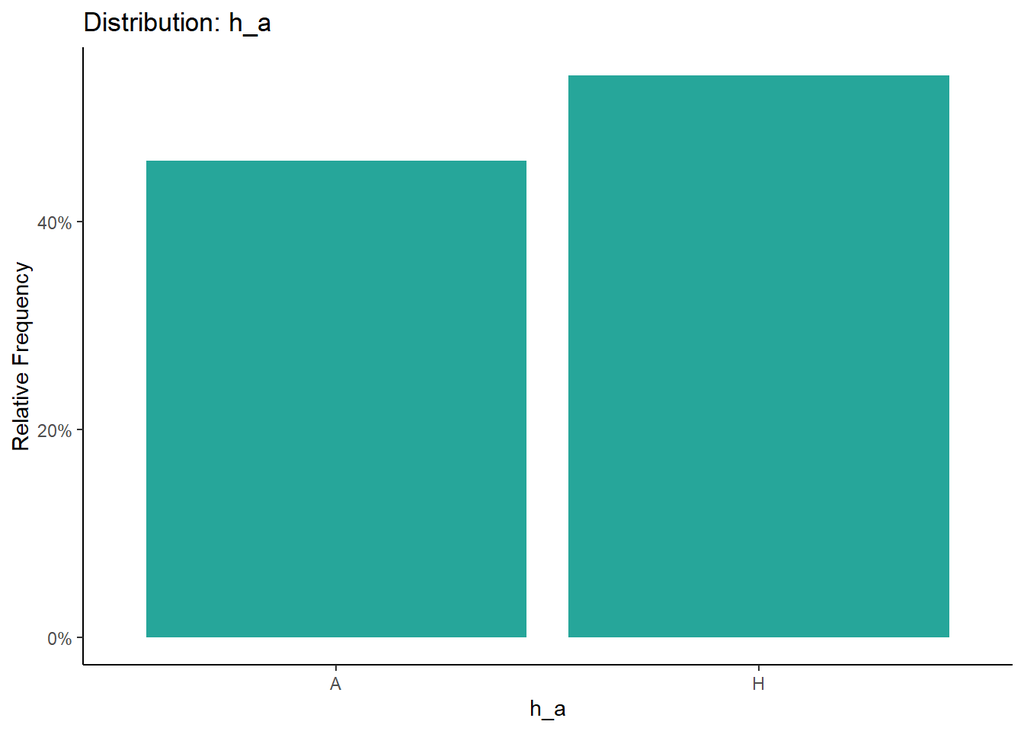

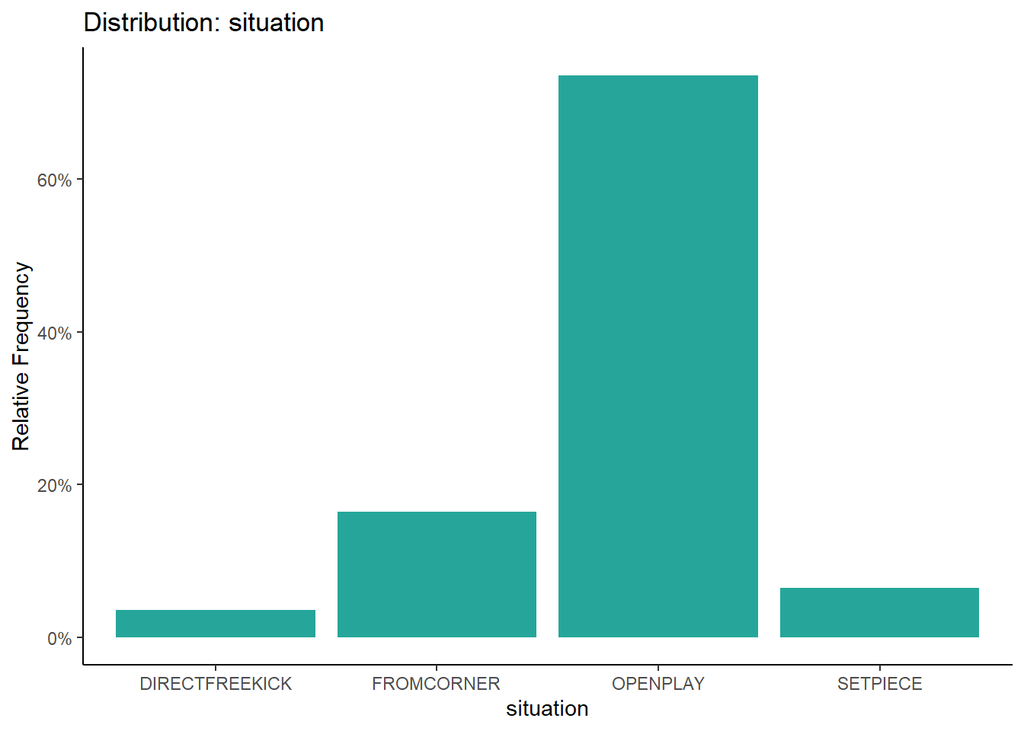

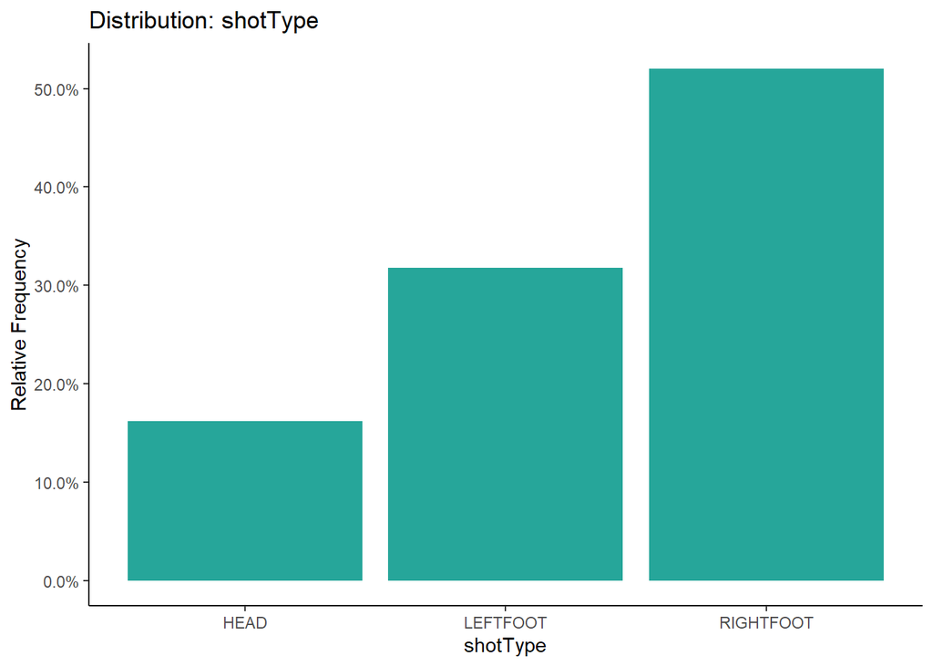

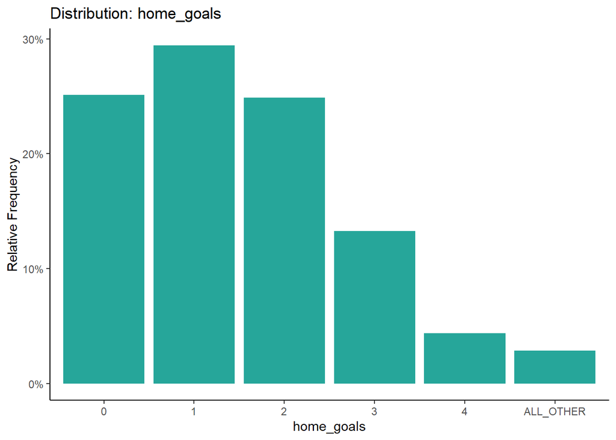

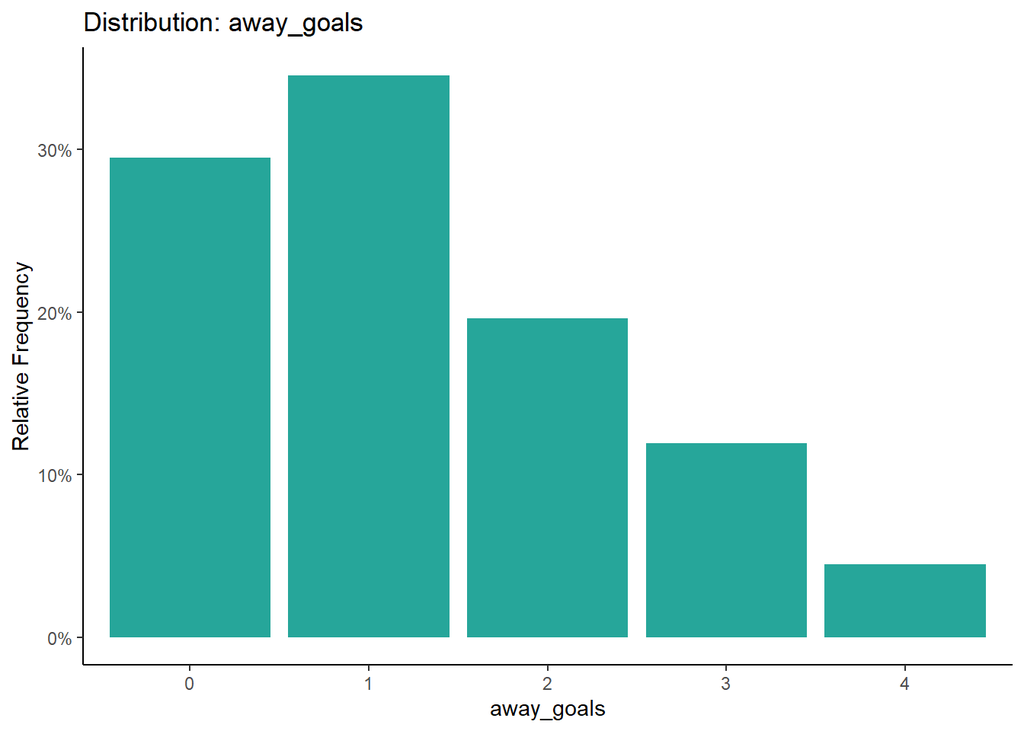

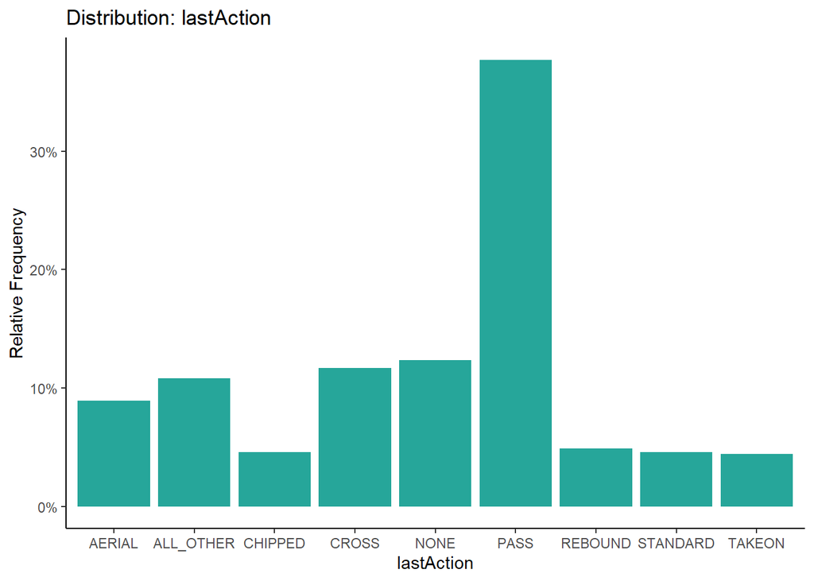

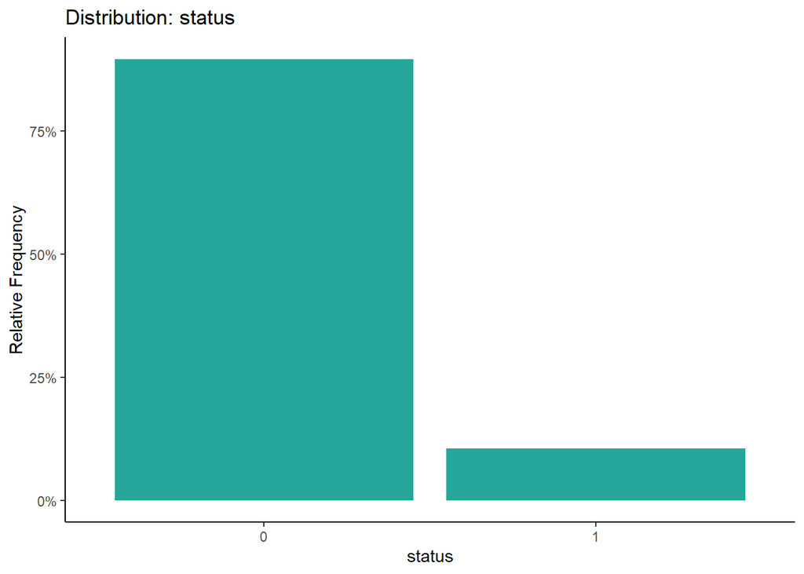

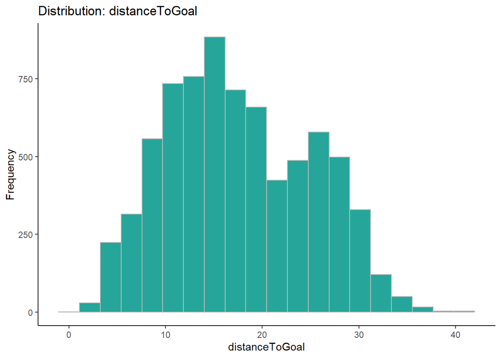

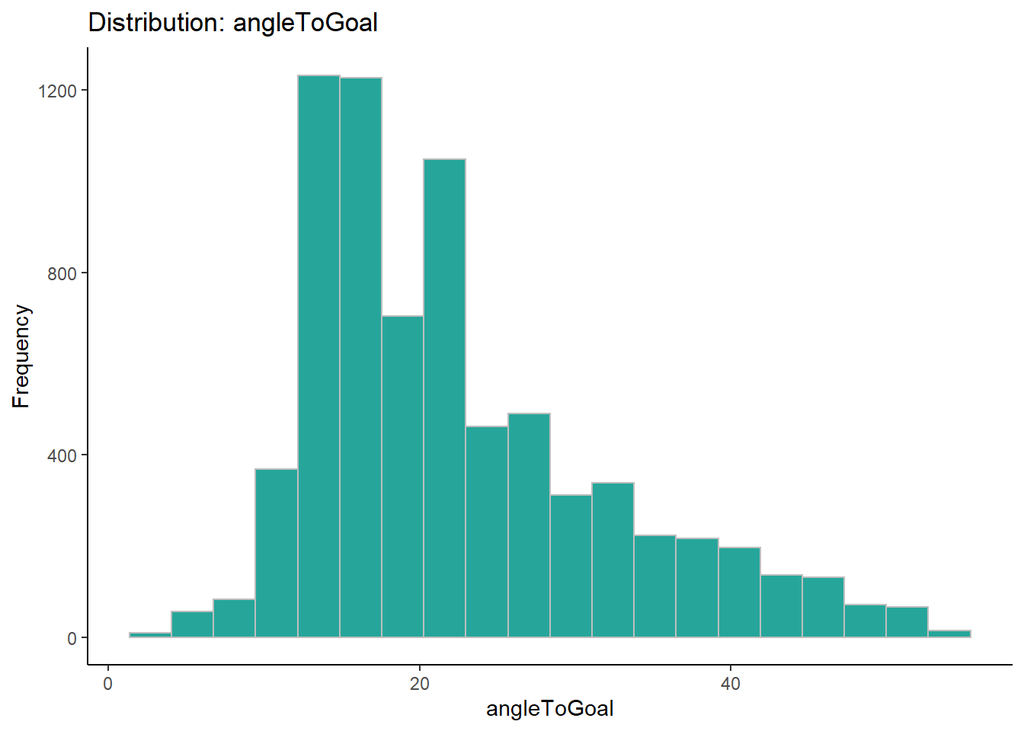

| Feature | Observations | FeatureClass | FeatureType | PercentageMissing | PercentageUnique | ConstantFeature | ZeroSpreadFeature | LowerOutliers | UpperOutliers | ImputationValue | MinValue | FirstQuartile | Median | Mean | Mode | ThirdQuartile | MaxValue | LowerOutlierValue | UpperOutlierValue |
| --- | --- | --- | --- | --- | --- | --- | --- | --- | --- | --- | --- | --- | --- | --- | --- | --- | --- | --- | --- |
| xG | 7389 | numeric | Continuous | 0 | 98.63 | No | No | 0 | 1030 | 0.0542520619928837 | 0.0000000 | 0.02629865 | 0.05 | 0.11 | 0.761168837547302 | 0.09721443 | 0.9739642 | -0.08007501 | 0.2035881 |
| h_a | 7389 | character | Categorical | 0 | 0.03 | No | No | 0 | 0 | H | 0.0000000 | 0.00000000 | 0.00 | 0.00 | H | 0.00000000 | 0.0000000 | 0.00000000 | 0.0000000 |
| situation | 7389 | character | Categorical | 0 | 0.07 | No | No | 0 | 0 | OPENPLAY | 0.0000000 | 0.00000000 | 0.00 | 0.00 | OPENPLAY | 0.00000000 | 0.0000000 | 0.00000000 | 0.0000000 |
| shotType | 7389 | character | Categorical | 0 | 0.05 | No | No | 0 | 0 | RIGHTFOOT | 0.0000000 | 0.00000000 | 0.00 | 0.00 | RIGHTFOOT | 0.00000000 | 0.0000000 | 0.00000000 | 0.0000000 |
| home_goals | 7389 | character | Categorical | 0 | 0.11 | No | No | 0 | 0 | ALL_OTHER | 0.0000000 | 0.00000000 | 0.00 | 0.00 | 1 | 0.00000000 | 0.0000000 | 0.00000000 | 0.0000000 |
| away_goals | 7389 | character | Categorical | 0 | 0.08 | No | No | 0 | 0 | 1 | 0.0000000 | 0.00000000 | 0.00 | 0.00 | 1 | 0.00000000 | 0.0000000 | 0.00000000 | 0.0000000 |
| lastAction | 7389 | character | Categorical | 0 | 0.38 | No | No | 0 | 0 | ALL_OTHER | 0.0000000 | 0.00000000 | 0.00 | 0.00 | PASS | 0.00000000 | 0.0000000 | 0.00000000 | 0.0000000 |
| status | 7389 | character | Categorical | 0 | 0.03 | No | No | 0 | 0 | 0 | 0.0000000 | 0.00000000 | 0.00 | 0.00 | 0 | 0.00000000 | 0.0000000 | 0.00000000 | 0.0000000 |
| distanceToGoal | 7389 | numeric | Continuous | 0 | 94.56 | No | No | 0 | 53 | 16.6783345054225 | 0.9736658 | 11.78211383 | 16.68 | 18.00 | 12.1678110192425 | 23.94356017 | 103.6538365 | -6.46005567 | 42.1857297 |
| angleToGoal | 7389 | numeric | Continuous | 0 | 94.56 | No | No | 0 | 387 | 20.2968977869496 | 2.0520442 | 15.01748764 | 20.30 | 24.95 | 33.2803475559272 | 30.38175750 | 89.8709556 | -8.02891714 | 53.4281623 |

## Preparing models:

Our task is to create a classification model to predict, whether a shot attempt is “Goal” or not (based on target feature status).

```r
library(ranger)
library(DALEX)
library(DALEXtra)
```

Choosing extracting target column and remove that from training data

```r
xG_col <- df_1 %>% select(xG)

df_1 <- df_1 %>% select(-xG) %>% mutate(h_a = as.factor(h_a),
                                        situation = as.factor(situation),
                                        shotType = as.factor(shotType),
                                        lastAction = as.factor(lastAction),
                                        status = as.numeric(status))
c_target <- df_1 %>% select(status)
df_1 <- df_1 %>% select(-status)

library(caret)
dummy <- dummyVars(" ~.", data=df_1)
newdata <- cbind(data.frame(predict(dummy, newdata = df_1)),c_target)
model <- ranger::ranger(status ~., data = newdata, classification = TRUE, probability = TRUE)
```

We need to be cautious since dataset was not split into train and test.

## Homework

#### Making prediction:

We are about making prediction for the 12-th observation in dataset:

```r
new_obs <- newdata[12, !(colnames(newdata) %in% c("status"))]
predict_12 <- predict(model, new_obs)
print(ifelse(predict_12$predictions[2]<=0.5,0,1))
```

```
## [1] 0
```

```r
value_12 <- newdata[12, "status"]
print(value_12)
```

```
## [1] 0
```

Our ranger model returned with probability 0.0138631 for observation 12-th.

#### Explain model

Create explainer wrapper:

```r
explainer <- explain(model, data = newdata, y = as.numeric(newdata$status), label = 'ranger model')
```

```
## Preparation of a new explainer is initiated
##   -> model label       :  ranger model
##   -> data              :  7389  rows  44  cols
##   -> target variable   :  7389  values
##   -> predict function  :  yhat.ranger  will be used (  default  )
##   -> predicted values  :  No value for predict function target column. (  default  )
##   -> model_info        :  package ranger , ver. 0.13.1 , task classification (  default  )
##   -> predicted values  :  numerical, min =  0.004803582 , mean =  0.1049024 , max =  0.8466732
##   -> residual function :  difference between y and yhat (  default  )
##   -> residuals         :  numerical, min =  -0.772055 , mean =  -0.000422797 , max =  0.902818
##   A new explainer has been created!
```

“Break Down for selected observation” We use `predict_parts` to explain what contribute to the outcome of prediction for obs 12-th:

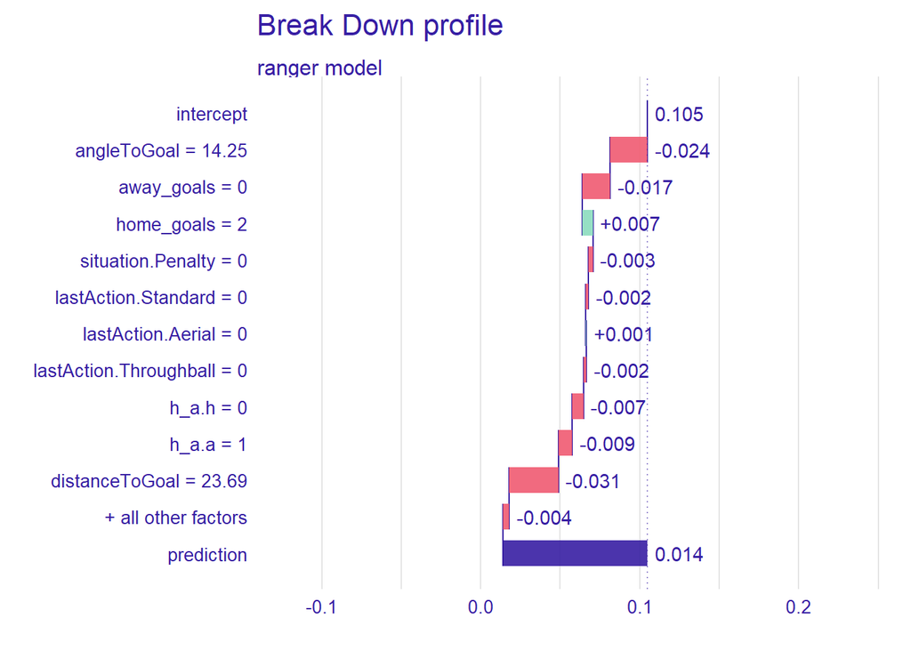

```r
bdown<- predict_parts(explainer = explainer, new_observation = new_obs)
plot(bdown)
```

The distance to the goal mouth contributes mostly for the failure of goal attempt for observation number 12-th.

“Shap & interation between features”

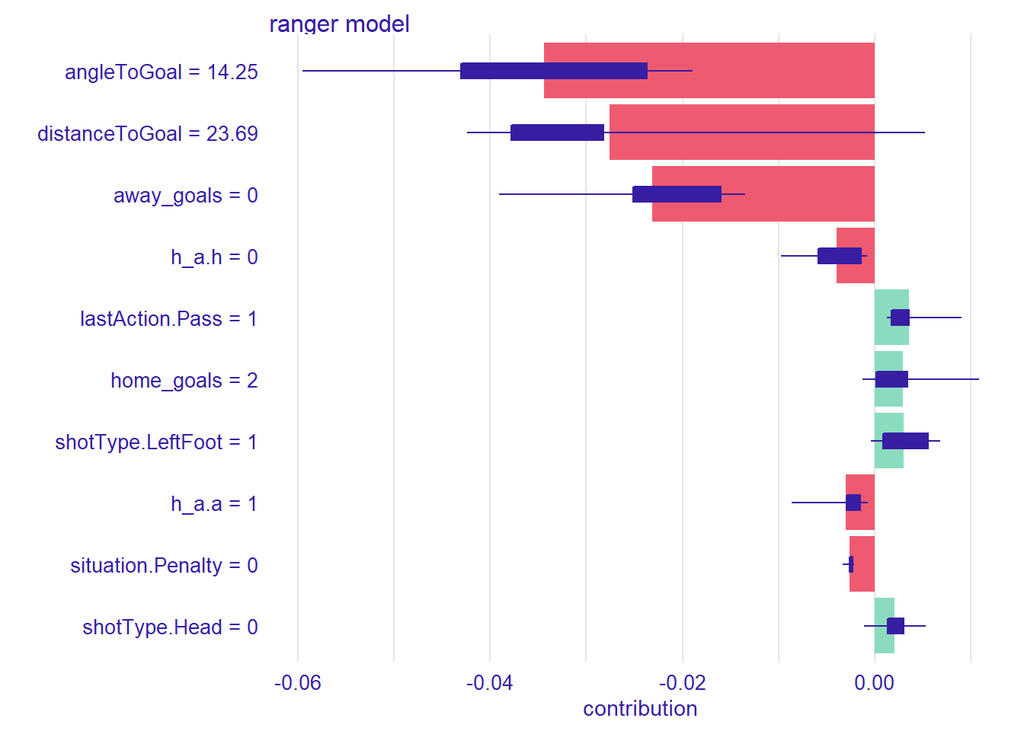

```r
shap <- predict_parts(explainer = explainer, new_observation = new_obs, type = 'shap', B = 5)
plot(shap)
```

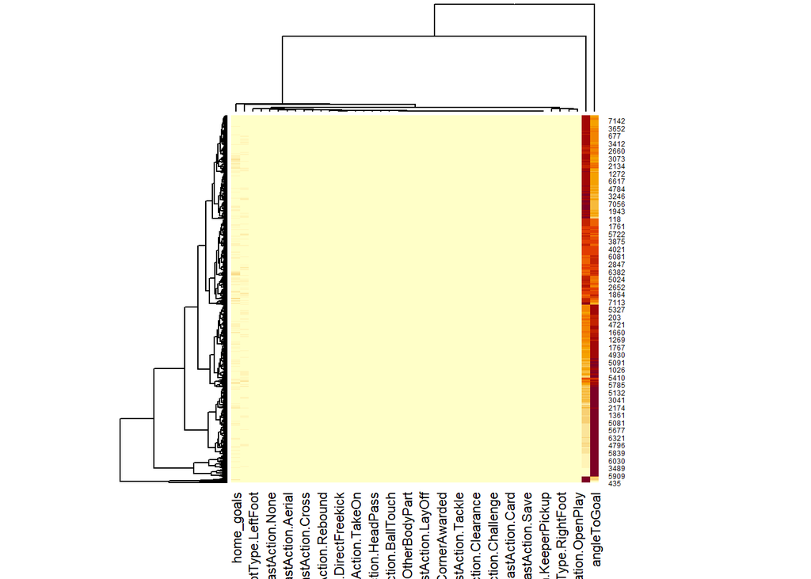

```r
heatmap(as.matrix(newdata[, !(colnames(newdata) %in% c("status"))]))
```

“Different effects”

Breakdown plot for observation no.12

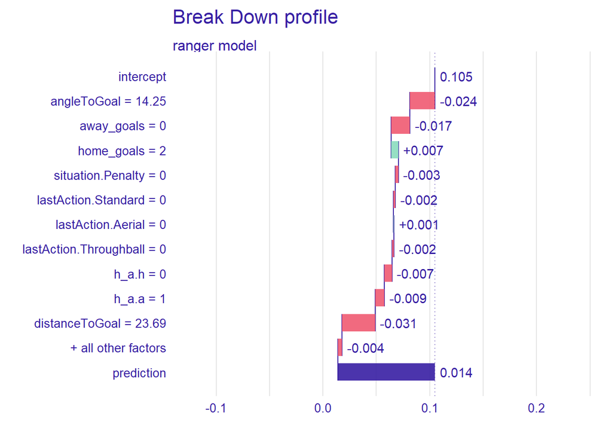

```r
bdown<- predict_parts(explainer = explainer, new_observation = new_obs)
plot(bdown)
```

Breakdown plot for observation no.123

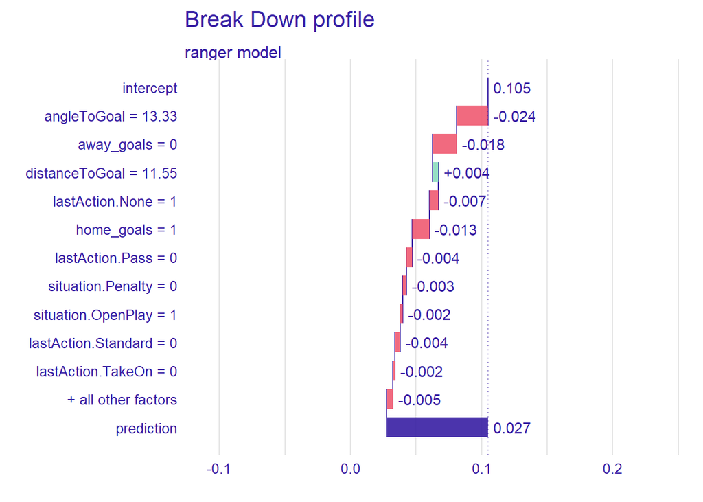

```r
bdown123 <- predict_parts(explainer = explainer, new_observation = newdata[123, !(colnames(newdata) %in% c("status"))])
plot(bdown123)
```

As we can see, variable distance to Goal, depending on its value, may contribute positively or negatively to our prediction.